# Data Cleaning

ANLY-511-04 Group 3

12/06/2022

```r
# load libraries for this assignment
library(tidyverse)
library(ggplot2)
library(readxl)
library(knitr)
library(kableExtra)
```

### Functions for Use

```r
calculate_proportions <- function(input_df, threshold) {

  # create data frame for printing proportions of of NA values
  df <- data.frame(colnames(input_df), round(colMeans(is.na(input_df)), 5), row.names = NULL)
  colnames(df) <- c('Column Name', 'Proportion of Values NA')
  df <- df[order(df$`Proportion of Values NA`, decreasing = TRUE),]
  df_table <- df[df$`Proportion of Values NA` > threshold,]

  return (df_table)
}
```

```r
print_table <- function(input_table) {
  knitr::kable(input_table, row.names = FALSE) %>% kable_styling(bootstrap_options = "striped", full_width = F, position = "center")
}
```

```r
print_shape <- function(input_df) {
  print(paste('Our dataset shape is now: (', nrow(input_df), ', ', ncol(input_df), ')', sep = ''))
}
```

### Read in the Data

Let’s first read in the data. We have five datasets to read in, all by the naming convention of `data/cardataXX.xlsx`, where `XX` $\in$ `{18, 19, 20, 21, 22}`. We can also observe the *shape* of each dataset, indicated with the following syntax: `(number of rows, number of columns)`.

```r
# load in the data
cardata2018 <- read_excel('../data/cardata2018.xlsx')
cardata2019 <- read_excel('../data/cardata2019.xlsx')
cardata2020 <- read_excel('../data/cardata2020.xlsx')
cardata2021 <- read_excel('../data/cardata2021.xlsx')
cardata2022 <- read_excel('../data/cardata2022.xlsx')
```

| Dataset Name | Shape |
| --- | --- |
| data/cardata2018.xlsx | (4727, 67) |
| data/cardata2019.xlsx | (4719, 67) |
| data/cardata2020.xlsx | (4450, 67) |
| data/cardata2021.xlsx | (4265, 67) |
| data/cardata2022.xlsx | (4455, 67) |

The five datasets come from the same source, but we want to ensure that they are compatible with one-another. The best way to check this is to ensure that the columns are the same across all datasets. If they are, we can easily append the five datasets together, by row, in order to create one, larger dataset.

```r
# extract column names for each dataset
colnames2018 <- colnames(cardata2018)
colnames2019 <- colnames(cardata2019)
colnames2020 <- colnames(cardata2020)
colnames2021 <- colnames(cardata2021)
colnames2022 <- colnames(cardata2022)

# ensure that the column names are all the same across all datasets
if ( mean(colnames2018 == colnames2019) == 1 &
     mean(colnames2018 == colnames2020) == 1 &
     mean(colnames2018 == colnames2021) == 1 &
     mean(colnames2018 == colnames2022) == 1 ) {
  print('The column names are the same and in the same order across all five datasets.')
} else {
  print('The column names are NOT the same and in the same order across all five datasets.')
}
```

```
## [1] "The column names are the same and in the same order across all five datasets."
```

Let’s append these datasets together since we know now that they have the same structure and column names.

```r
# bind datasets together by row
cardata <- rbind(cardata2018, cardata2019, cardata2020, cardata2021, cardata2022)
print_shape(cardata)
```

```
## [1] "Our dataset shape is now: (22616, 67)"
```

There are also some columns that we are not concerned with for the purpose of our analysis, so we will drop those before proceeding with the cleaning phase. These columns are:

- `Test Vehicle ID`
- `Test Veh Configuration #`
- `Actual Tested Testgroup`
- `Engine Code`
- `Transmission Overdrive Code`
- `Transmission Overdrive Desc`
- `Shift Indicator Light Use Cd`
- `Shift Indicator Light Use Desc`
- `Test Number`
- `Test Originator`
- `Analytically Derived FE?`
- `ADFE Test Number`
- `Test Procedure Cd`
- `Test Procedure Description`
- `Test Fuel Type Cd`
- `Test Category`
- `FE_UNIT`
- `FE Bag 1`
- `FE Bag 2`
- `FE Bag 3`
- `FE Bag 4`

```r
# define columns to remove
remove <- c("Test Vehicle ID", "Test Veh Configuration #", "Actual Tested Testgroup",
            "Engine Code", "Transmission Overdrive Code", "Transmission Overdrive Desc",
            "Shift Indicator Light Use Cd", "Shift Indicator Light Use Desc", "Test Number",
            "Test Originator", "Analytically Derived FE?", "ADFE Test Number",
            "Test Procedure Cd", "Test Procedure Description", "Test Fuel Type Cd",
            "Test Category", "FE_UNIT", "FE Bag 1",
            "FE Bag 2", "FE Bag 3", "FE Bag 4")

# remove columns and report new shape
cardata <- cardata[, !( colnames(cardata) %in% remove)]
print_shape(cardata)
```

```
## [1] "Our dataset shape is now: (22616, 46)"
```

### Split Data into Two

Since one large are of focus of ours is comparing electric vehicles to non-electric vehicles, we will split our dataset into two groups: one containing only electric vehicles and one containing only non-electric vehicles. This will allow us to make easy comparisons both between datasets and within datasets.

```r
# look at the unique fuel types
unique(cardata$`Test Fuel Type Description`)
```

```
##  [1] "Tier 2 Cert Gasoline"
##  [2] "Cold CO Premium (Tier 2)"
##  [3] "Federal Cert Diesel 7-15 PPM Sulfur"
##  [4] "Electricity"
##  [5] "Cold CO Regular (Tier 2)"
##  [6] "E85 (85% Ethanol 15% EPA Unleaded Gasoline)"
##  [7] "Tier 3 E10 Regular Gasoline (9 RVP @Low Alt.)"
##  [8] "Hydrogen 5"
##  [9] "Cold CO E10 Premium Gasoline (Tier 3)"
## [10] "Tier 3 E10 Premium Gasoline (9 RVP @Low Alt.)"
## [11] "CARB Phase II Gasoline"
## [12] "Cold CO Diesel 7-15 ppm Sulfur"
## [13] "CARB LEV3 E10 Regular Gasoline"
```

Observing the unique fuel types above, we will split the dataset on cars with `Test Fuel Type Description` labeled as `Electricity` or `Hydrogen 5`, leaving the remaining fuel types for the other dataset.

```r
# split the dataset in two
cardata_electric <- cardata[cardata$`Test Fuel Type Description` %in% c('Electricity', 'Hydrogen 5'),]
cardata_nonelectric <- cardata[!(cardata$`Test Fuel Type Description` %in% c('Electricity', 'Hydrogen 5')),]
```

### Address Missing Values by Column

Now, with the columns that we do have, we can observe how many `NA` values exist in each column. We will set a threshold of **10%**; a column with more than 10 percent of its values being `NA` expresses a large number of missing values in our eyes and we will remove it from our analysis. Below, we can see all columns expressing more than 10% of their values as `NA`.

```r
# print the proportions of NA values in each column using a threshold of 10%
electric_table <- calculate_proportions(cardata_electric, 0.10)
nonelectric_table <- calculate_proportions(cardata_nonelectric, 0.10)
print_table(electric_table)
```

| Column Name | Proportion of Values NA |
| --- | --- |
| ADFE Total Road Load HP | 1.00000 |
| ADFE Equiv. Test Weight (lbs.) | 1.00000 |
| ADFE N/V Ratio | 1.00000 |
| THC (g/mi) | 1.00000 |
| CO2 (g/mi) | 1.00000 |
| PM (g/mi) | 1.00000 |
| CH4 (g/mi) | 1.00000 |
| N2O (g/mi) | 1.00000 |
| Averaging Group ID | 0.96811 |
| CO (g/mi) | 0.93850 |
| Averaging Weighting Factor | 0.92711 |
| NOx (g/mi) | 0.90774 |
| # of Cylinders and Rotors | 0.86105 |
| Aftertreatment Device Cd | 0.86105 |
| Aftertreatment Device Desc | 0.86105 |
| DT-Inertia Work Ratio Rating | 0.85991 |
| DT-Absolute Speed Change Ratg | 0.85991 |
| DT-Energy Economy Rating | 0.85991 |
| RND_ADJ_FE | 0.15034 |

```r
print_table(nonelectric_table)
```

| Column Name | Proportion of Values NA |
| --- | --- |
| Averaging Group ID | 0.98114 |
| Averaging Weighting Factor | 0.97249 |
| ADFE Total Road Load HP | 0.88683 |
| ADFE Equiv. Test Weight (lbs.) | 0.88683 |
| ADFE N/V Ratio | 0.88683 |
| PM (g/mi) | 0.81990 |
| N2O (g/mi) | 0.47796 |
| CH4 (g/mi) | 0.15457 |
| NOx (g/mi) | 0.10907 |

We can then remove these columns from each respective dataset. Note that the `RND_ADJ_FE` and `CO2 (g/mi)` variables are ones that we’d like to work with, however, so we will keep those regardless of their missing value counts.

```r
# remove high-probability NA columns from data frame
remove_electric <- electric_table$`Column Name`
remove_electric <- remove_electric[!(remove_electric %in% c('RND_ADJ_FE', 'CO2 (g/mi)'))]
remove_nonelectric <- nonelectric_table$`Column Name`

# remove columns and report new shape
cardata_electric <- cardata_electric[, !( colnames(cardata_electric) %in% remove_electric)]
cardata_nonelectric <- cardata_nonelectric[, !( colnames(cardata_nonelectric) %in% remove_nonelectric)]
print_shape(cardata_electric)
```

```
## [1] "Our dataset shape is now: (878, 29)"
```

```r
print_shape(cardata_nonelectric)
```

```
## [1] "Our dataset shape is now: (21738, 37)"
```

### Electric Vehicle Data

```r
# print the proportions of NA values in each column using a threshold of 0%
electric_table <- calculate_proportions(cardata_electric, 0)
print_table(electric_table)
```

| Column Name | Proportion of Values NA |
| --- | --- |
| CO2 (g/mi) | 1.00000 |
| RND_ADJ_FE | 0.15034 |

We can see that the electric vehicle data only has two columns with missing values: `RND_ADJ_FE` and `CO2 (g/mi)`. We’ve decided to keep the `CO2 (g/mi)` in order to provide comparisons between the electric and non-electric vehicle data, but we want to address the specific missing values of the `RND_ADJ_FE` variable. This variable is an expression of miles per gallon. Let’s take a look at a histogram of this variable.

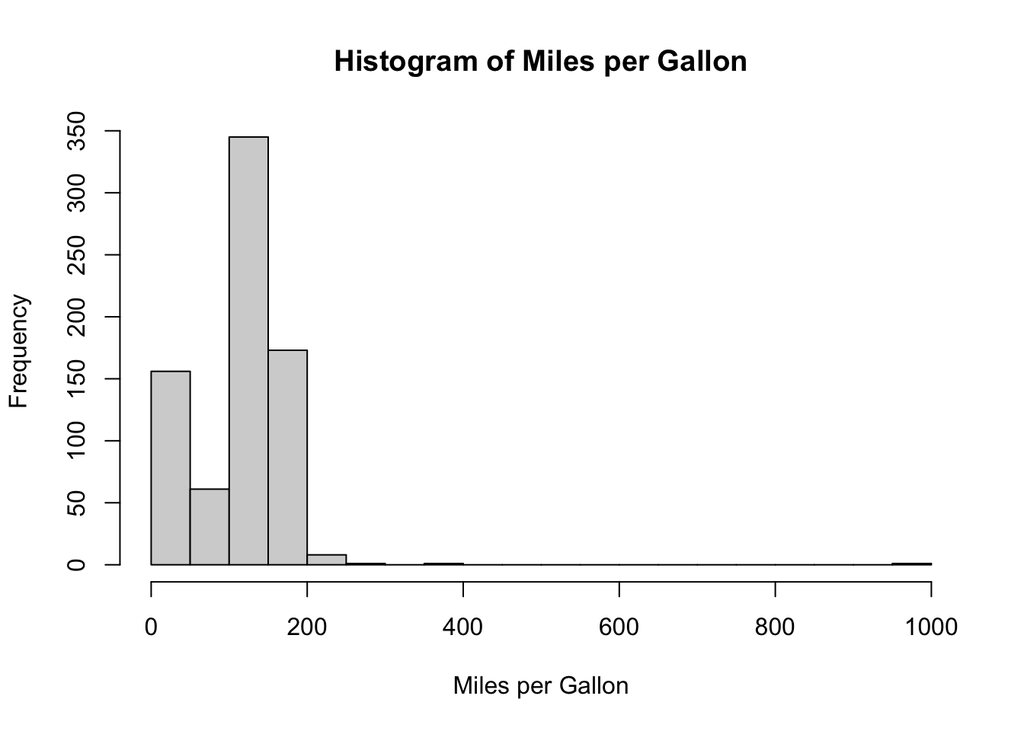

```r
# plot histogram of the electric car MPG values
hist(cardata_electric$RND_ADJ_FE, xlab = 'Miles per Gallon', main = 'Histogram of Miles per Gallon', breaks = 20)
```

We can see that there is at least one outlier on the high end of the distribution, expressing a value of 1000. We will replace these value(s) with missing values in order to obtain results that have more validity. We will then replace the missing values with the *median* value of the distribution, as this is a safer way to do so without making any bold assumptions.

```r
# replace high outliers with missing value
cardata_electric$RND_ADJ_FE[cardata_electric$RND_ADJ_FE > 500] <- NA
# replace missing values with the median value
cardata_electric$RND_ADJ_FE[is.na(cardata_electric$RND_ADJ_FE)] <- median(cardata_electric$RND_ADJ_FE, na.rm = TRUE)
```

We can now observe the columns with missing values in the electric vehicle dataset and notice that we have cleaned it to our liking. Note that the `CO2 (g/mi)` variable still remains and will likely be interpreted as **0** emission from these electric vehicles.

```r
# print the proportions of NA values in each column using a threshold of 0%
electric_table <- calculate_proportions(cardata_electric, 0)
print_table(electric_table)
```

| Column Name | Proportion of Values NA |
| --- | --- |
| CO2 (g/mi) | 1 |

### Non-Electric Vehicle Data

We still have columns expressing `NA` values for the non-electric vehicle dataset. These columns, of course, have less than 10% of their values being `NA`, after the removal performed above. These columns can be seen below.

```r
# print the proportions of NA values in each column using a threshold of 0%
nonelectric_table <- calculate_proportions(cardata_nonelectric, 0)
print_table(nonelectric_table)
```

| Column Name | Proportion of Values NA |
| --- | --- |
| THC (g/mi) | 0.09803 |
| CO (g/mi) | 0.09789 |
| DT-Inertia Work Ratio Rating | 0.04835 |
| DT-Absolute Speed Change Ratg | 0.04835 |
| DT-Energy Economy Rating | 0.04835 |
| CO2 (g/mi) | 0.01702 |
| Aftertreatment Device Cd | 0.00888 |
| Aftertreatment Device Desc | 0.00888 |
| RND_ADJ_FE | 0.00823 |
| # of Cylinders and Rotors | 0.00745 |

#### `DT-Inertia Work Ratio Rating`, `DT-Absolute Speed Change Ratg`, and `DT-Energy Economy Rating`

Let’s start by observing these three variables:

- `DT-Inertia Work Ratio Rating`
- `DT-Absolute Speed Change Ratg`
- `DT-Energy Economy Rating`

We can make histograms to see what their distributions are like.

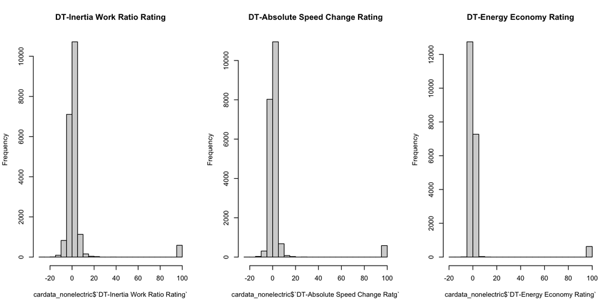

```r
par(mfrow = c(1, 3))
hist(cardata_nonelectric$`DT-Inertia Work Ratio Rating`, main = 'DT-Inertia Work Ratio Rating', breaks = 20)
hist(cardata_nonelectric$`DT-Absolute Speed Change Ratg`, main = 'DT-Absolute Speed Change Rating', breaks = 20)
hist(cardata_nonelectric$`DT-Energy Economy Rating`, main = 'DT-Energy Economy Rating', breaks = 20)
```

It is evident that each of these columns has a set of observations marked with a rating around $100$. This is likely comparable to an `NA` value, as the distribution of values for these attributes is almost entirely hovering around a value of $0$. Let’s replace these values with `NA` values so that we don’t confuse ourselves with them being valid. Then, since the remaining distribution appears to be very symmetric, we can replace the missing values with the mean of the column for each variable.

```r
# replace high outliers with NA
cardata_nonelectric$`DT-Inertia Work Ratio Rating`[cardata_nonelectric$`DT-Inertia Work Ratio Rating` > 50] <- NA
cardata_nonelectric$`DT-Absolute Speed Change Ratg`[cardata_nonelectric$`DT-Absolute Speed Change Ratg` > 50] <- NA
cardata_nonelectric$`DT-Energy Economy Rating`[cardata_nonelectric$`DT-Energy Economy Rating` > 50] <- NA

# replace missing values with the mean value
cardata_nonelectric$`DT-Inertia Work Ratio Rating`[is.na(cardata_nonelectric$`DT-Inertia Work Ratio Rating`)] <- mean(cardata_nonelectric$`DT-Inertia Work Ratio Rating`, na.rm = TRUE)
cardata_nonelectric$`DT-Absolute Speed Change Ratg`[is.na(cardata_nonelectric$`DT-Absolute Speed Change Ratg`)] <- mean(cardata_nonelectric$`DT-Absolute Speed Change Ratg`, na.rm = TRUE)
cardata_nonelectric$`DT-Energy Economy Rating`[is.na(cardata_nonelectric$`DT-Energy Economy Rating`)] <- mean(cardata_nonelectric$`DT-Energy Economy Rating`, na.rm = TRUE)
```

We can now observe our new, updated measurements of proportions of values in columns that are `NA`.

```r
# create data frame for printing proportions of NA values
nonelectric_table <- calculate_proportions(cardata_nonelectric, 0)
print_table(nonelectric_table)
```

| Column Name | Proportion of Values NA |
| --- | --- |
| THC (g/mi) | 0.09803 |
| CO (g/mi) | 0.09789 |
| CO2 (g/mi) | 0.01702 |
| Aftertreatment Device Cd | 0.00888 |
| Aftertreatment Device Desc | 0.00888 |
| RND_ADJ_FE | 0.00823 |
| # of Cylinders and Rotors | 0.00745 |

#### `Aftertreatment Device Cd` and `Aftertreatment Device Desc`

The following two variables have the same number of missing values in the dataset. Let’s see if they are from the same rows.

- `Aftertreatment Device Cd`
- `Aftertreatment Device Desc`

```r
# extract row names where these three variables are missing
after_cd_null <- rownames(cardata_nonelectric[is.na(cardata_nonelectric$`Aftertreatment Device Cd`), ])
after_desc_null <- rownames(cardata_nonelectric[is.na(cardata_nonelectric$`Aftertreatment Device Desc`), ])

# ensure that the column names are all the same across all datasets
if ( mean(after_cd_null == after_desc_null) == 1 ) {
  print('These variables are missing in the same rows in the dataset.')
} else {
  print('These variables are missing in different rows in the dataset.')
}
```

```
## [1] "These variables are missing in the same rows in the dataset."
```

The last few variables containing missing values left to address are:

- `THC (g/mi)`
- `CO (g/mi)`
- `CO2 (g/mi)`
- `# of Cylinders and Rotors`
- `RND_ADJ_FE`

#### `THC (g/mi)`, `CO (g/mi)`, and `CO2 (g/mi)`

Let’s start with these variables and observe their missing values.

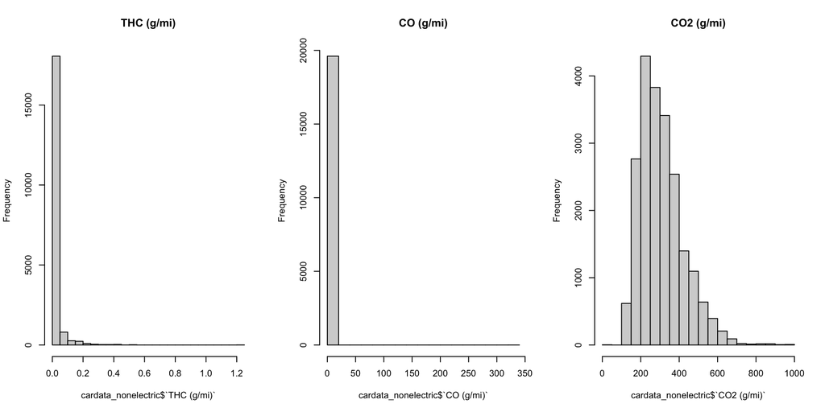

```r
par(mfrow = c(1, 3))
hist(cardata_nonelectric$`THC (g/mi)`, main = 'THC (g/mi)', breaks = 20)
hist(cardata_nonelectric$`CO (g/mi)`, main = 'CO (g/mi)', breaks = 20)
hist(cardata_nonelectric$`CO2 (g/mi)`, main = 'CO2 (g/mi)', breaks = 20)
```

```r
# replace missing values with the mean value
cardata_nonelectric$`THC (g/mi)`[is.na(cardata_nonelectric$`THC (g/mi)`)] <- mean(cardata_nonelectric$`THC (g/mi)`, na.rm = TRUE)
cardata_nonelectric$`CO (g/mi)`[is.na(cardata_nonelectric$`CO (g/mi)`)] <- mean(cardata_nonelectric$`CO (g/mi)`, na.rm = TRUE)
cardata_nonelectric$`CO2 (g/mi)`[is.na(cardata_nonelectric$`CO2 (g/mi)`)] <- mean(cardata_nonelectric$`CO2 (g/mi)`, na.rm = TRUE)
```

#### `# of Cylinders and Rotors`

Let’s move on to `# of Cylinders and Rotors`.

```r
# table of number of cylinders
table(cardata_nonelectric$`# of Cylinders and Rotors`)
```

```
##
##     2     3     4     5     6     8    10    12    16
##    21   390 10709    45  6531  3333   166   350    31
```

We can see above that the number of cylinders and rotors is almost exclusively an even number, with values of $3$ and $5$ appearing some number of times.

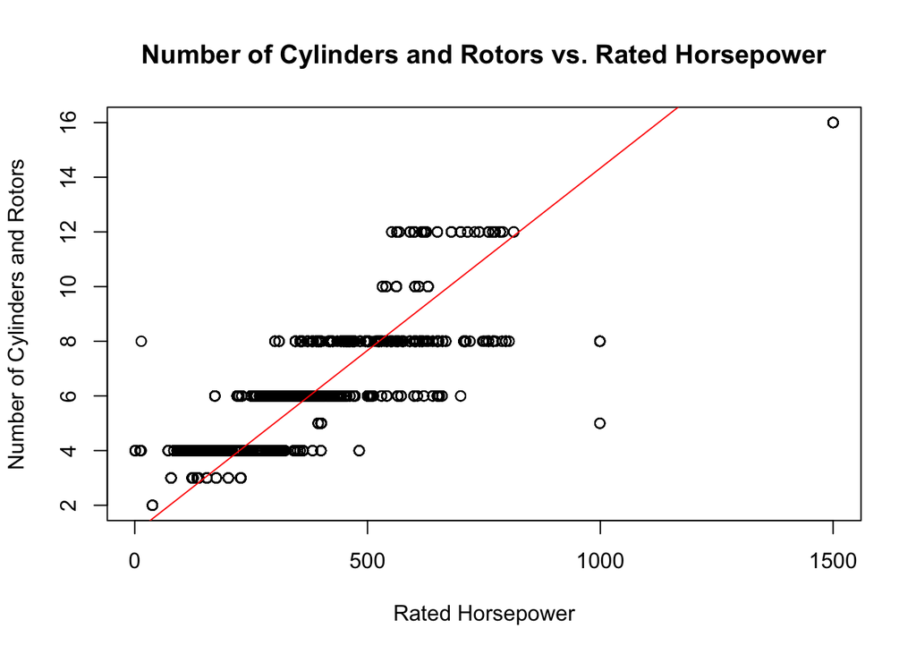

```r
# plot number of cylinders versus horsepower
plot(cardata_nonelectric$`Rated Horsepower`, cardata_nonelectric$`# of Cylinders and Rotors`, xlab = 'Rated Horsepower', ylab = 'Number of Cylinders and Rotors', main = 'Number of Cylinders and Rotors vs. Rated Horsepower')
abline(a = 1, b = 1/75, col = 'red')
```

Above, we can see an approximation of the number of cylinders (`# of Cylinders and Rotors`) and rotors predicted by the horsepower (`Rated Horsepower`). Using this approximation, we will fill in the missing values of `# of Cylinders and Rotors` using the nearest even value. Note that the even values make up the vast majority in this dataset, as values of $1$, $3$, and $5$, for instance, are very rare.

```r
# replace missing cylinder values with the approximation above
for (i in 1:nrow(cardata_nonelectric)) {
  if (is.na(cardata_nonelectric$`# of Cylinders and Rotors`[i])) {
    val <- 1 + cardata_nonelectric$`Rated Horsepower`[i] / 75
    cardata_nonelectric$`# of Cylinders and Rotors`[i] <- round(val / 2) * 2
  }
}
```

#### `RND_ADJ_FE`

Finally, let’s move on to `RND_ADJ_FE`.

As we did above with the electric vehicles, let’s observe a histogram of the `RND_ADJ_FE` variable for the non-electric vehicles. Remember, this variable expresses the number of miles per gallon for the vehicle.

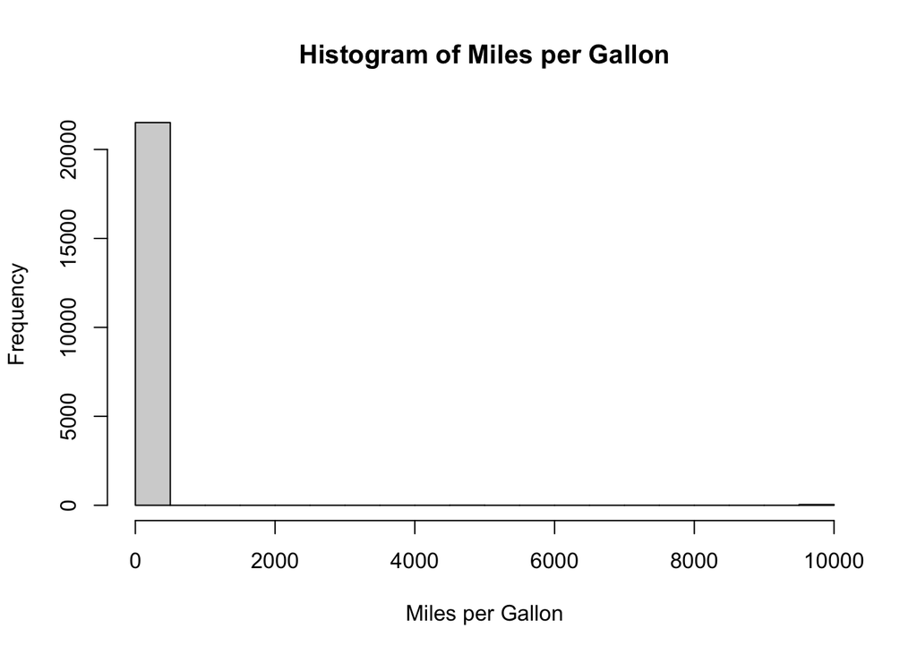

```r
# plot histogram of the electric car MPG values
hist(cardata_nonelectric$RND_ADJ_FE, xlab = 'Miles per Gallon', main = 'Histogram of Miles per Gallon', breaks = 20)
```

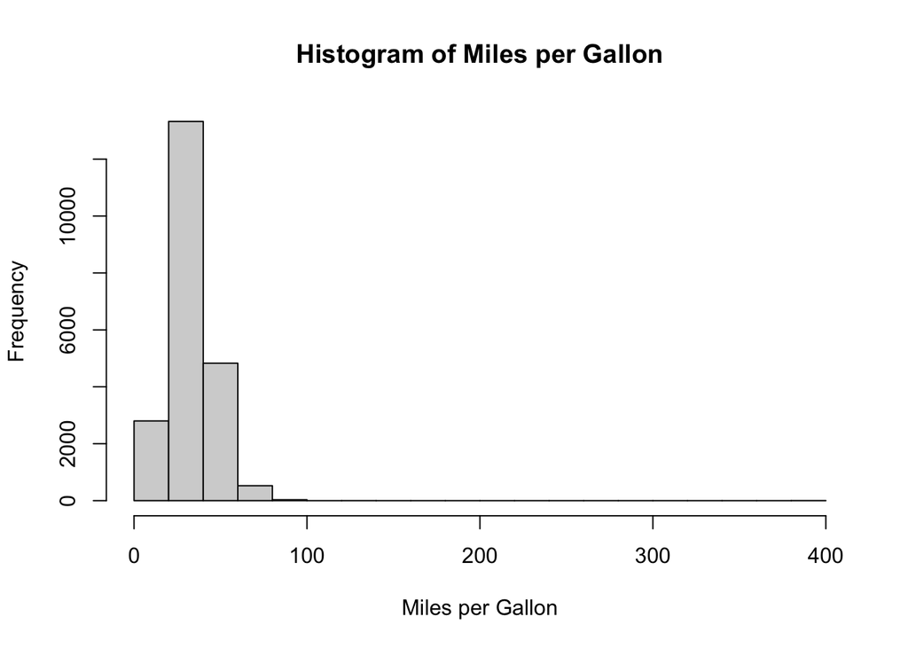

```r
# replace high outliers with missing value
cardata_nonelectric$RND_ADJ_FE[cardata_nonelectric$RND_ADJ_FE > 500] <- NA

# plot histogram of the electric car MPG values
hist(cardata_nonelectric$RND_ADJ_FE, xlab = 'Miles per Gallon', main = 'Histogram of Miles per Gallon', breaks = 20)
```

We will perform the same task as before with the electric vehicles by replacing the missing values in this column with the *median* value of the distribution, as this is a safer way to do so without making any bold assumptions.

```r
# replace missing values with the median value
cardata_nonelectric$RND_ADJ_FE[is.na(cardata_nonelectric$RND_ADJ_FE)] <- median(cardata_nonelectric$RND_ADJ_FE, na.rm = TRUE)
```

```r
# print the proportions of NA values in each column using a threshold of 0%
nonelectric_table <- calculate_proportions(cardata_nonelectric, 0)
print_table(nonelectric_table)
```

| Column Name | Proportion of Values NA |
| --- | --- |
| Aftertreatment Device Cd | 0.00888 |
| Aftertreatment Device Desc | 0.00888 |

### Final Look

Let’s take a look at the proportions of missing values now, as we have addressed them all (and kept some).

```r
# print the proportions of NA values in each column
electric_table <- calculate_proportions(cardata_electric, 0)
nonelectric_table <- calculate_proportions(cardata_nonelectric, 0)
print_table(electric_table)
```

| Column Name | Proportion of Values NA |
| --- | --- |
| CO2 (g/mi) | 1 |

```r
print_table(nonelectric_table)
```

| Column Name | Proportion of Values NA |
| --- | --- |
| Aftertreatment Device Cd | 0.00888 |
| Aftertreatment Device Desc | 0.00888 |

After addressing the missing values in the data, we find that we only have approximately **0.15%** of our data missing. This is a great improvement from the **15.64%** that we had initially and something that we can take with us as we look to analyze the data further.

### Export Clean Data

Finally, we need to export this cleaned data so that we can use it in our analyses.

```r
write.csv(cardata_electric, '../data/cardata_electric_clean.csv')
write.csv(cardata_nonelectric, '../data/cardata_nonelectric_clean.csv')
```